# Supervised learning applied to transaction approval

by Giancarlo Marchesi

This notebook contains the analysis for a series of credit scoring models for a small direct account payment gateway company.

A payment gateway is a merchant service provided by an e-commerce application company that authorizes credit card or direct payments processing for e-businesses, online retailers, bricks and clicks, or traditional brick and mortar. This particular gateway company authorizes direct payments to merchants from customers' bank accounts. The gateway has no online connection to banks, so it must rely on its own scoring models to determine which customers to approve. Bad transactions occur when customers do not have funds in their accounts at the time. Merchants get paid immediately, so default risk stays with the gateway company.

The company currently has access to scores from two credit rating providers, yet still uses a manual process to approve the transactions. Unless they get specific confirmation by phone from the customer's bank that the customer's account is empty, the transaction is approved. Hence, they are not leveraging the data from the providers. Bad (insolvent) transactions are frequent. The client wants to know how to use the data they have effectively to have a better risk model and be more profitable. The sector in which the company operates is risky. The commerces do not take credit cards, only direct payments. Commerces that use these methods generally attract riskier clients.

## Objective

The objective of the project is to help the company maximize profits by approving the most amount of good transactions and limiting the bad ones. The business loses 100% of bad transactions and charges 5% of good transactions.

The analysis presents alternative credit scoring models using supervised machine learning methods that combine these scores and other available data. The data is from a private direct payment processing company. Only features pertaining to the analysis are shown in the dataset.

**Model alternatives:**

- Use only independent `score 1` as is
- Use only independend `score 2` as is
- Use an interaction of scores 1 and 2 (two versions)
- Use a logistic regression model
- Use a KNN model

The working hypothesis is that both ML models will provide additional insight to the independent scores.

## Exploring the data

- The dataset has 824 observations, so it is relatively small.
- The number of bad transactions is 153 (18.56%). So the company's problem is serious. On the positive side for the analysis, we are not facing an unbalanced sample.
- Average dollar amount per transaction:
  - Good transactions: 74.23
  - Bad transactions: 77.73

## The business problem

According to the dataset, this is the current state of the business:

- Income from good transactions: 2490.5
- Loss from bad transactions: -11892
- **Net loss: -9401.5**

The company lost USD 9400 because their credit scoring process is lacking. It does not really account for risk, since it approves most transactions. The CEO wants to know how to reduce bad transactions to increase profits (or decrease losses).

The analysis will center on finding the best classification model to max profits/minimize losses from the following alternatives:

- Credit Score 1
- Credit Score 2
- Interactions of Score 1 and Score 2
- Logistic regression model
- KNN model

## Model 1: Credit Score 1

The accuracy of Credit Score 1 can be analyzed with a confusion matrix. This classifies transactions in four groups:

```
(true label, predicted label)
```

- True positives: transactions that the score predicted would be losses and indeed the customer had no funds (1,1)
- True negatives: transactions that the score predicted would be good transactions and indeed were good (0,0)
- False positives: transactions that the score predicted would be bad were actually good (0,1)
- False negatives: transactions that the score predicted would be good and were actually bad (1,0)

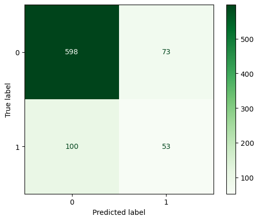

Remember, '1' is a bad transaction, i.e. "a positive" in the nomenclature.

The matrix is read in the following way:

- (1,1). True positives. The transaction was bad and the model predicted it as such. 53
- (0,0). True negative. The transaction was good and the model predicted it as such. 598
- (0,1). False positive. The transaction was good but the model predicted it would be bad. 73
- (1,0). False negative. The transaccion was bad, but the model predicted it would be good. 100

The first two are exactly what the model is supposed to screen. False positives would be opportunity costs: revenue not generated because of a stringent risk model. False negatives are unidentified losses by the model. These generate the losses. So the adequacy of the model for the purpose of the business is finding the right balance between these two quadrants.

### Profit

**Results for Model Score_1:**

1. Accuracy: percentage of trues that the model gets correctly. score: 79%. Mediocre.
2. Precision: measures what proportion of a model assigned to positive are actually members of the positive class. score: 42%. Not very precise. More false positives are more than true positives.
3. Recall: measures how many members of the positive class the model correctly identified out of the total. 35%.

Not good. More false negatives than true positives.

**Business metrics:**

- Income from good transactions: 2224.45
- Loss from bad transactions: -7654
- **Net loss: -5429.55**

So by using the score from provider 1, the company has saved 3972 dollars (i.e. a smaller net loss) versus not using a score at all. However, they are still operating at a loss of 5429 dollars. The problem is that false negatives are very costly.

## Model 2: Credit Score 2

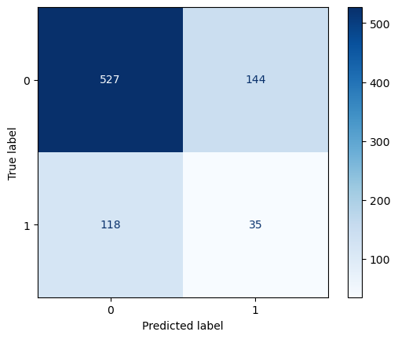

**Results for Model Score_2:**

1. Accuracy: percentage of trues that the model gets correctly. 68%. Bad.
2. Precision: measures what proportion of a model assigned to positive are actually members of the positive class. 20%. Very bad.
3. Recall: measures how many members of the positive class the model correctly identified out of the total. 23%. Very bad.

On all metrics, it is inferior to model 1. Hence, the loss will be worse. No need to calculate profit here.  
Estimations are done in the notebook.

## Model 3: Interaction of Score 1 & Score 2

Interaction_1 only has 42 positives. Considering there are 153 positives in the database. This does not bode well. No need to calculate profit here.

Interaction_2 has 323 positives, so at least has a chance to catch all positives, but it's clear it will have a problem with false positives, as it doubles the amount of positives. It will reduce revenue for the company while overestimating risk. Let's conduct the exercise to calculate profits under this model.

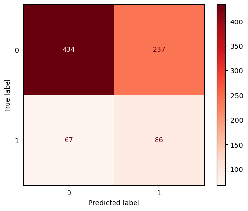

**Results for interaction_2 model**

- Accuracy: percentage of trues that the model gets correctly. 63%. Bad.
- Precision: measures what proportion of a model assigned to positive are actually members of the positive class. 27%. Very bad.
- Recall: measures how many members of the positive class the model correctly identified out of the total. 56%. Bad, but better than the previous models. This might help mitigate the false negatives and avoid losses.

**Business metrics:**

- Income from good transactions: 1616.40
- Loss from bad transactions: -5223
- **Net loss: -3606.60**

Total revenue takes a substantial hit from losing the false positive revenue. This is the best model so far, as the loss is smallest, USD 3607. This is because recall is the most important of the measures in terms for this particular business model.

## Model 4: Logistic Regression

### Using Scikit Learn

```
[[646  25]
 [128  25]]
```

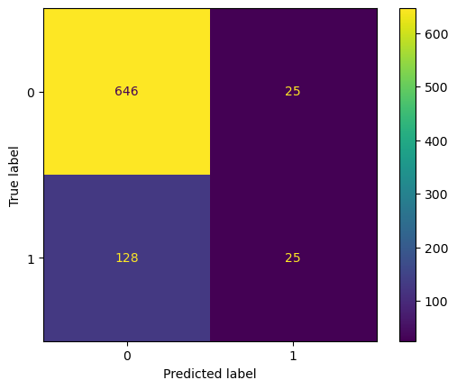

```
              precision    recall  f1-score   support

           0       0.83      0.96      0.89       671
           1       0.50      0.16      0.25       153

    accuracy                           0.81       824
   macro avg       0.67      0.56      0.57       824
weighted avg       0.77      0.81      0.77       824
```

The recall of this model is very bad. No need to calculate profits here. We have tried the scikit learn method, but we can also run the regression using the statsmodels api and setting the threshold differently, to reduce the number of false negatives.

### Using the statsmodel API

```
The used threshold is 0.25
              precision    recall  f1-score   support

           0       0.89      0.83      0.85       671
           1       0.41      0.54      0.47       153

    accuracy                           0.77       824
   macro avg       0.65      0.68      0.66       824
weighted avg       0.80      0.77      0.78       824
```

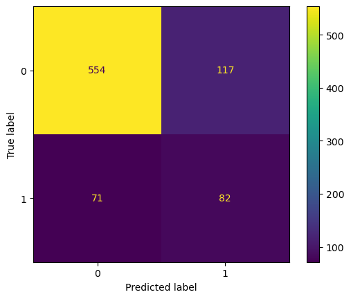

**Business metrics:**

- Income from good transactions: 2032
- Loss from bad transactions: -5317
- **Net loss: -3284.70**

This is a better model than interaction_2, as the loss is smallest, USD 3284.70. Income is slightly better in this case, while losses are similar.

## Model 5: KNN

```
KNN estimation using 5 neighbors
              precision    recall  f1-score   support

           0       0.86      0.96      0.91       671
           1       0.64      0.31      0.42       153

    accuracy                           0.84       824
   macro avg       0.75      0.64      0.66       824
weighted avg       0.82      0.84      0.82       824
```

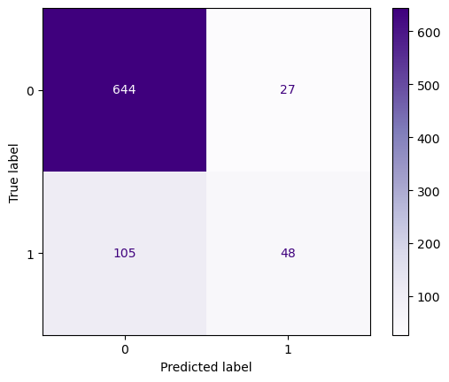

**Business metrics for KNN model:**

- Income from good transactions: 2380.5
- Loss from bad transactions: -8032
- **Net loss: -5651.5**

This is a worse model because of a lower recall.

## Conclusion

- The company is losing money and needs to introduce some type of risk scoring system.
- In terms of practicality, since the company is already paying for but not using Score 1 or Score 2, it should begin filtering clients using an interaction term of the two. The more stringent definition of risk diminishes net loss from 9400 dollars to 3607. This can be implemented right away so the company loses less money.
- There are not enough observations yet to conduct a proper ML analysis with train and test sets.
- Nevertheless, the logistic regression model using the Stats API does provide a smaller loss when the threshold for positivity is lowered to 0.25. The recall for this model is similar to that of interaction_2, yet it identifies more true negatives.
- Overall, low accuracy, precision and recall are indicative of insuficient data, not just in quantity of observations but perhaps also in additional features to explain the target.